# Practical Machine Learning Course Project

René Marves

July 21, 2017

## Data Setup

Loading the required libraries.

```r
library(caret); library(rattle); library(rpart); library(rpart.plot)
library(randomForest); library(repmis); library(gbm)
```

Now we load the data.

```r
full.training <- read.csv("pml-training.csv", na.strings = c("NA", ""))
testing <- read.csv("pml-testing.csv", na.strings = c("NA", ""))
```

## Preparation

Now, we clean the data and prepare for creating the predictive model. The first 7 columns of data are not actually relevant to the predictions, so they are removed first. Then, the variables with near-zero variance, which don’t provide as valuable information for the prediction and then the variables with NAs, which would generate errors in the prediction models.

```r
# Remove first 7 predictors
full.training <- full.training[, -c(1:7)]
testing <- testing[, -c(1:7)]

# Removes near zero variance variables
full.training <- full.training[, -nearZeroVar(full.training)]
testing <- testing[, -nearZeroVar(testing)]

# Removes variables with NAs
full.training <- full.training[, colSums(is.na(full.training)) == 0]
testing <- testing[, colSums(is.na(testing)) == 0]
```

After that, the data is split into training and validation subsets to create the model.

```r
# Splits the data set into training and validation
set.seed(4321)
record.split <- createDataPartition(full.training$classe, p = 0.7, list = FALSE)
training <- full.training[record.split, ]
validation <- full.training[-record.split, ]
```

## Prediction Algorithm

There are several prediction algorithms used, but foor brevetiy’s sake, we’ll just present the one that worked best: Random Forests.

The algorithm is constructed using therandomForest package, which breaks down the training data into branches randomly and creates a tree that becomes the prediction model.

```r
control <- trainControl(method = "cv", number = 5)
pmodel <- train(classe ~ ., data = training, method = "rf",
                   trControl = control)
print(pmodel, digits = 4)
```

```
## Random Forest
##
## 13737 samples
##    52 predictor
##     5 classes: 'A', 'B', 'C', 'D', 'E'
##
## No pre-processing
## Resampling: Cross-Validated (5 fold)
## Summary of sample sizes: 10990, 10989, 10990, 10991, 10988
## Resampling results across tuning parameters:
##
##   mtry  Accuracy  Kappa
##    2    0.9897    0.9869
##   27    0.9897    0.9870
##   52    0.9828    0.9783
##
## Accuracy was used to select the optimal model using  the largest value.
## The final value used for the model was mtry = 27.
```

```r
# predict outcomes using validation set
predict.rf <- predict(pmodel, validation)
# Show prediction result
(conf.rf <- confusionMatrix(validation$classe, predict.rf))
```

```
## Confusion Matrix and Statistics
##
##           Reference
## Prediction    A    B    C    D    E
##          A 1673    0    0    0    1
##          B   10 1124    4    0    1
##          C    0    4 1016    6    0
##          D    0    0    6  957    1
##          E    0    0    3    6 1073
##
## Overall Statistics
##
##                Accuracy : 0.9929
##                  95% CI : (0.9904, 0.9949)
##     No Information Rate : 0.286
##     P-Value [Acc > NIR] : < 2.2e-16
##
##                   Kappa : 0.991
##  Mcnemar's Test P-Value : NA
##
## Statistics by Class:
##
##                      Class: A Class: B Class: C Class: D Class: E
## Sensitivity            0.9941   0.9965   0.9874   0.9876   0.9972
## Specificity            0.9998   0.9968   0.9979   0.9986   0.9981
## Pos Pred Value         0.9994   0.9868   0.9903   0.9927   0.9917
## Neg Pred Value         0.9976   0.9992   0.9973   0.9976   0.9994
## Prevalence             0.2860   0.1917   0.1749   0.1647   0.1828
## Detection Rate         0.2843   0.1910   0.1726   0.1626   0.1823
## Detection Prevalence   0.2845   0.1935   0.1743   0.1638   0.1839
## Balanced Accuracy      0.9969   0.9967   0.9927   0.9931   0.9977
```

The model accuracy is:

```r
(accuracy.rf <- conf.rf$overall[1])
```

```
##  Accuracy
## 0.9928632
```

and the expected out of sample error is 100% - 99.3% = 0.7%, which has been cross-validated with the validation subset of training set.

## Predicting the Test Set

Now, we use the model to predict the test results:

```r
(predict(pmodel, testing))
```

```
##  [1] B A B A A E D B A A B C B A E E A B B B
## Levels: A B C D E
```

## Appendix: Other prediction models

Here are the other prediction models that were created and not used, as they provided less accuracy than the one used.

### Classification trees

```r
control <- trainControl(method = "cv", number = 5)
tree.model <- train(classe ~ ., data = training, method = "rpart",
                   trControl = control)
print(tree.model, digits = 4)
```

```
## CART
##
## 13737 samples
##    52 predictor
##     5 classes: 'A', 'B', 'C', 'D', 'E'
##
## No pre-processing
## Resampling: Cross-Validated (5 fold)
## Summary of sample sizes: 10990, 10990, 10989, 10990, 10989
## Resampling results across tuning parameters:
##
##   cp       Accuracy  Kappa
##   0.03621  0.5043    0.35252
##   0.06001  0.4395    0.24869
##   0.11535  0.3493    0.09929
##
## Accuracy was used to select the optimal model using  the largest value.
## The final value used for the model was cp = 0.03621.
```

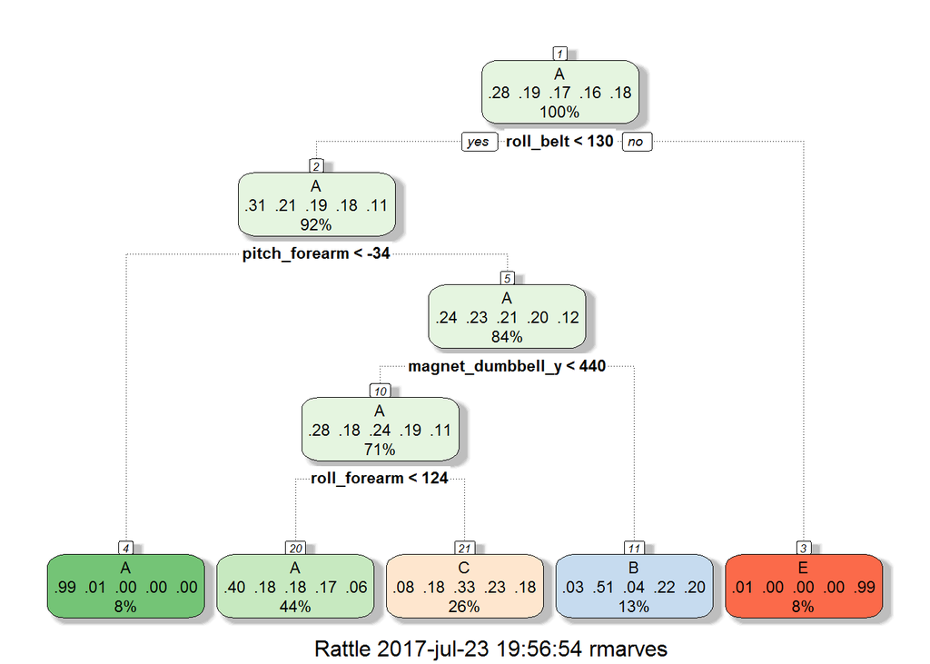

```r
fancyRpartPlot(tree.model$finalModel)
```

```r
# Test prediction using validation set
tree.predict <- predict(tree.model, validation)
# Show result
(tree.conf <- confusionMatrix(validation$classe, tree.predict))
```

```
## Confusion Matrix and Statistics
##
##           Reference
## Prediction    A    B    C    D    E
##          A 1532   24  116    0    2
##          B  469  382  288    0    0
##          C  468   41  517    0    0
##          D  427  184  353    0    0
##          E  152  134  311    0  485
##
## Overall Statistics
##
##                Accuracy : 0.4955
##                  95% CI : (0.4826, 0.5084)
##     No Information Rate : 0.5179
##     P-Value [Acc > NIR] : 0.9997
##
##                   Kappa : 0.3408
##  Mcnemar's Test P-Value : NA
##
## Statistics by Class:
##
##                      Class: A Class: B Class: C Class: D Class: E
## Sensitivity            0.5026  0.49935  0.32618       NA  0.99589
## Specificity            0.9499  0.85215  0.88163   0.8362  0.88940
## Pos Pred Value         0.9152  0.33538  0.50390       NA  0.44824
## Neg Pred Value         0.6400  0.91930  0.78020       NA  0.99958
## Prevalence             0.5179  0.12999  0.26933   0.0000  0.08275
## Detection Rate         0.2603  0.06491  0.08785   0.0000  0.08241
## Detection Prevalence   0.2845  0.19354  0.17434   0.1638  0.18386
## Balanced Accuracy      0.7263  0.67575  0.60391       NA  0.94265
```

```r
(accuracy.tree <- tree.conf$overall[1])
```

```
## Accuracy
## 0.495497
```

### Generalized Boosted Regression

```r
gbr.control <- trainControl(method = "repeatedcv", number = 5, repeats = 1)
gbm.fit <- train(classe ~ ., data=training, method = "gbm",
                 trControl = gbr.control, verbose = FALSE)
gbm.model <- gbm.fit$finalModel
gbm.validation <- predict(gbm.fit, newdata=validation)
(gbm.accuracy <- confusionMatrix(gbm.validation, validation$classe))
```

```
## Confusion Matrix and Statistics
##
##           Reference
## Prediction    A    B    C    D    E
##          A 1655   37    0    0    3
##          B   16 1071   34    2    7
##          C    2   29  978   26   14
##          D    1    1   11  929   23
##          E    0    1    3    7 1035
##
## Overall Statistics
##
##                Accuracy : 0.9631
##                  95% CI : (0.958, 0.9678)
##     No Information Rate : 0.2845
##     P-Value [Acc > NIR] : < 2.2e-16
##
##                   Kappa : 0.9533
##  Mcnemar's Test P-Value : 1.005e-05
##
## Statistics by Class:
##
##                      Class: A Class: B Class: C Class: D Class: E
## Sensitivity            0.9886   0.9403   0.9532   0.9637   0.9566
## Specificity            0.9905   0.9876   0.9854   0.9927   0.9977
## Pos Pred Value         0.9764   0.9478   0.9323   0.9627   0.9895
## Neg Pred Value         0.9955   0.9857   0.9901   0.9929   0.9903
## Prevalence             0.2845   0.1935   0.1743   0.1638   0.1839
## Detection Rate         0.2812   0.1820   0.1662   0.1579   0.1759
## Detection Prevalence   0.2880   0.1920   0.1782   0.1640   0.1777
## Balanced Accuracy      0.9896   0.9639   0.9693   0.9782   0.9771
```